# session 3 visualization tests

Let’s load the different examples files. Replace the file path `C:/Users/dmog/Documents/cours/stat_2022/Travaux_Pratiques/Session3_tests/data/` with yours.

```r
library(ggplot2)
library(tidyr)
library(dplyr)
df_bisphenol <- read.csv("C:/Users/dmog/Documents/cours/stat_2022/Travaux_Pratiques/Session3_tests/data/ExerciceBisphenol.csv")

Bisphenol_long <- read.csv("C:/Users/dmog/Documents/cours/stat_2022/Travaux_Pratiques/Session3_tests/data/Bisphenol_long.csv")

plasma <- readxl::read_xlsx("C:/Users/dmog/Documents/cours/stat_2022/Travaux_Pratiques/Session3_tests/data/ExercicePlasmaCholesterol.xlsx")
```

# Data management knowledge

Ok I will try to summarise the data handling knowledge needed here at the begining:

## wide vs long format

```r
plasma
```

| Control | Treatment 1 | Treatment 2 |
| --- | --- | --- |
| 164.4 | 190.8 | 163.6 |
| 173.1 | 170.6 | 153.1 |
| 177.6 | 184.5 | 154.2 |
| 169.7 | 172.3 | 151.7 |
| 182.9 | 175.6 | 157.5 |
| 171.7 | 168.0 | 155.7 |
| 187.9 | 182.1 | 157.0 |
| 177.5 | 159.5 | 160.5 |
| 185.8 | 172.7 | 159.5 |
| 175.8 | 169.5 | 147.9 |

[output cut: 10 more lines]

Here the data are in wide format, i.e. one column per group. But all columns are the same measurement. You could use long format, i.e. one column for the measurement (plasma), one for the groups. The function from tidyr if `pivot_longer`

```r
pivot_longer(plasma,c("Control","Treatment 1","Treatment 2"))
```

| name | value |
| --- | --- |
| Control | 164.4 |
| Treatment 1 | 190.8 |
| Treatment 2 | 163.6 |
| Control | 173.1 |
| Treatment 1 | 170.6 |
| Treatment 2 | 153.1 |
| Control | 177.6 |
| Treatment 1 | 184.5 |
| Treatment 2 | 154.2 |
| Control | 169.7 |

[output cut: 50 more lines]

You can set the name of variable and value column directly in the function:

```r
plasma_long <- plasma %>%
  pivot_longer(c("Control","Treatment 1","Treatment 2"),
               names_to = "group",
               values_to = "plasma")
plasma_long
```

| group | plasma |
| --- | --- |
| Control | 164.4 |
| Treatment 1 | 190.8 |
| Treatment 2 | 163.6 |
| Control | 173.1 |
| Treatment 1 | 170.6 |
| Treatment 2 | 153.1 |
| Control | 177.6 |
| Treatment 1 | 184.5 |
| Treatment 2 | 154.2 |
| Control | 169.7 |

[output cut: 50 more lines]

## data frame selection

in R, we can have numbers, text (character) or factors. A factor is a variable than can only takes certain values. We can put this variables in a vector

```r
x <- c(3,2,4,5)
x
```

```
## [1] 3 2 4 5
```

x is a vector of 4 numbers. I can select these elements with squared brackets. here I select the first element:

```r
x[1]
```

```
## [1] 3
```

Here I select the first and third

```r
x[c(1,3)]
```

```
## [1] 3 4
```

If we put several vectors of same length together, we have a table, called data frame in R:

```r
df_bisphenol
```

| group | Cancer | NoCancer |
| --- | --- | --- |
| Control | 1 | 29 |
| Moderate exposition | 2 | 28 |
| High exposition | 10 | 20 |

here 3 columns, 3 lines. Each column is a vector. Selecting lines or columns with squared brackets

df_bisphenol[selectlines , selectcolumns]

### columns

To select one column:

```r
df_bisphenol$Cancer
```

```
## [1]  1  2 10
```

Or:

```r
df_bisphenol[,"Cancer"]
```

```
## [1]  1  2 10
```

or using the number of the column (here the second column):

```r
df_bisphenol[,2]
```

```
## [1]  1  2 10
```

If I select various columns, I obtain a new data frame:

```r
df_bisphenol[,c("Cancer","NoCancer")]
```

| Cancer | NoCancer |
| --- | --- |
| 1 | 29 |
| 2 | 28 |
| 10 | 20 |

same as

```r
df_bisphenol[,c(2,3)]
```

| Cancer | NoCancer |
| --- | --- |
| 1 | 29 |
| 2 | 28 |
| 10 | 20 |

### lines

To select lines, I can use the numbers of the lines I want to select,i.e. the first line and all columns:

```r
df_bisphenol[1,]
```

|  | group | Cancer | NoCancer |
| --- | --- | --- | --- |
| 1 | Control | 1 | 29 |

or the line 1 and 3

```r
df_bisphenol[c(1,3),]
```

|  | group | Cancer | NoCancer |
| --- | --- | --- | --- |
| 1 | Control | 1 | 29 |
| 3 | High exposition | 10 | 20 |

I can laso select lines using a boolean vector, i.e. a vector of true and false. Her I select the first line:

```r
df_bisphenol[c(TRUE,FALSE,FALSE),]
```

|  | group | Cancer | NoCancer |
| --- | --- | --- | --- |
| 1 | Control | 1 | 29 |

Why ? Because you can then use boolean operation to select lines. Here the boolean: group is equal to “Control”:

```r
df_bisphenol$group == "Control"
```

```
## [1]  TRUE FALSE FALSE
```

Can be used to select the first line:

```r
df_bisphenol[df_bisphenol$group == "Control",]
```

|  | group | Cancer | NoCancer |
| --- | --- | --- | --- |
| 1 | Control | 1 | 29 |

If we want the group to have several values (like “Control” and “High exposition”), the boolean looks like

```r
df_bisphenol$group %in% c("Control","High exposition")
```

```
## [1]  TRUE FALSE  TRUE
```

This operation reads: the vector df_bisphenol$group has value within c(“Control”,“High exposition”). The result says “yes, no, yes”. You can use that to select lines:

```r
df_bisphenol[df_bisphenol$group %in% c("Control","High exposition"),]
```

|  | group | Cancer | NoCancer |
| --- | --- | --- | --- |
| 1 | Control | 1 | 29 |
| 3 | High exposition | 10 | 20 |

an other example where it makes more sense (with df_bisphenol you could just use the line number): for the table Bisphenol_long, which contains a result with one line per patient (so 90 lines), we want to keep only the group “Control” and “High_expo”

```r
Bisphenol_long[Bisphenol_long$group %in% c("Control","High_expo"),]
```

|  | group | had_cancer | ID |
| --- | --- | --- | --- |
| 1 | Control | 0 | 1 |
| 2 | Control | 0 | 2 |
| 3 | Control | 0 | 3 |
| 4 | Control | 0 | 4 |
| 5 | Control | 0 | 5 |
| 6 | Control | 0 | 6 |
| 7 | Control | 0 | 7 |
| 8 | Control | 0 | 8 |
| 9 | Control | 0 | 9 |
| 10 | Control | 0 | 10 |

[output cut: 50 more lines]

# The tests

We want to make tests.

We will use

```r
t.test()
```

for the t test, and

```r
chisq.test()
```

for the chi2 test

Use the help to find how the functions work !!

```r
?chisq.test
?t.test
```

# plasma data

Measurement of plasma concentration for 3 groups: Control, treatment 1 and treatment 2.

**Question**: We want to see if there is a significant difference between each group. Do graphs, do tests.

## make some graph

Use the long or wide format to do some graphs

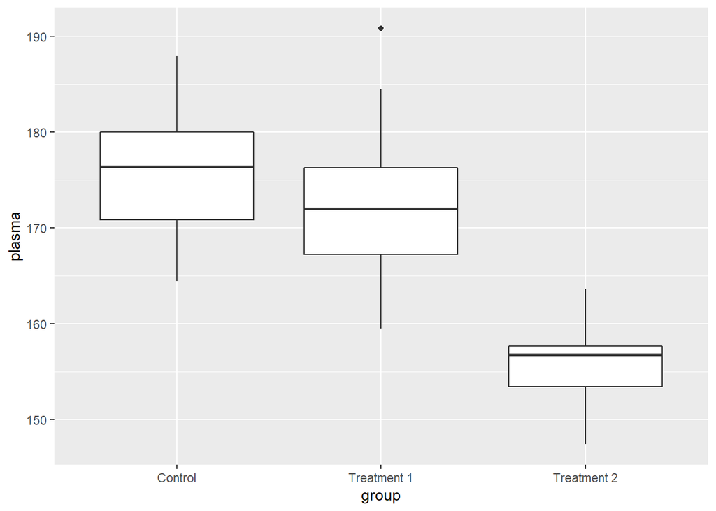

```r
ggplot(data = plasma_long,
       aes(group,plasma))+
  geom_boxplot()
```

The same with wide format:

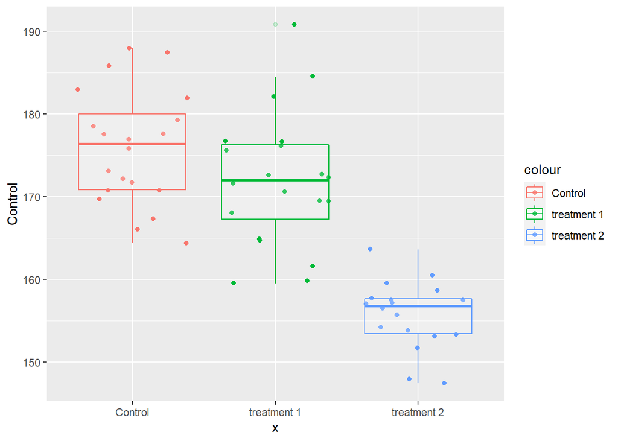

```r
ggplot(plasma)+
  geom_jitter(aes("Control",Control,color = "Control"))+
  geom_boxplot(aes("Control",Control,color = "Control"),alpha = .2)+
  geom_jitter(aes("treatment 1",`Treatment 1`,color = "treatment 1"))+
  geom_boxplot(aes("treatment 1",`Treatment 1`,color = "treatment 1"),alpha = .2)+
  geom_jitter(aes("treatment 2",`Treatment 2`,color ="treatment 2"))+
geom_boxplot(aes("treatment 2",`Treatment 2`,color ="treatment 2"),alpha = .2)
```

## make a test

which test ?

t-test

What does the test suppose ?

The test supposes normal distribution

make an histogram

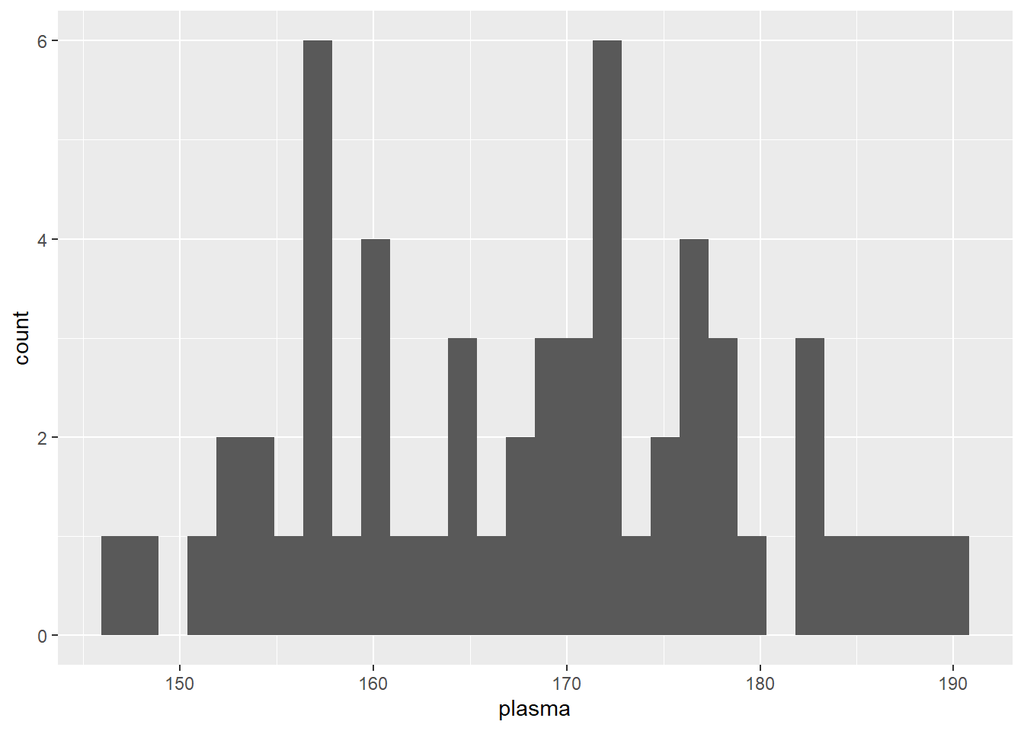

```r
ggplot(plasma_long,aes(plasma))+
  geom_histogram()
```

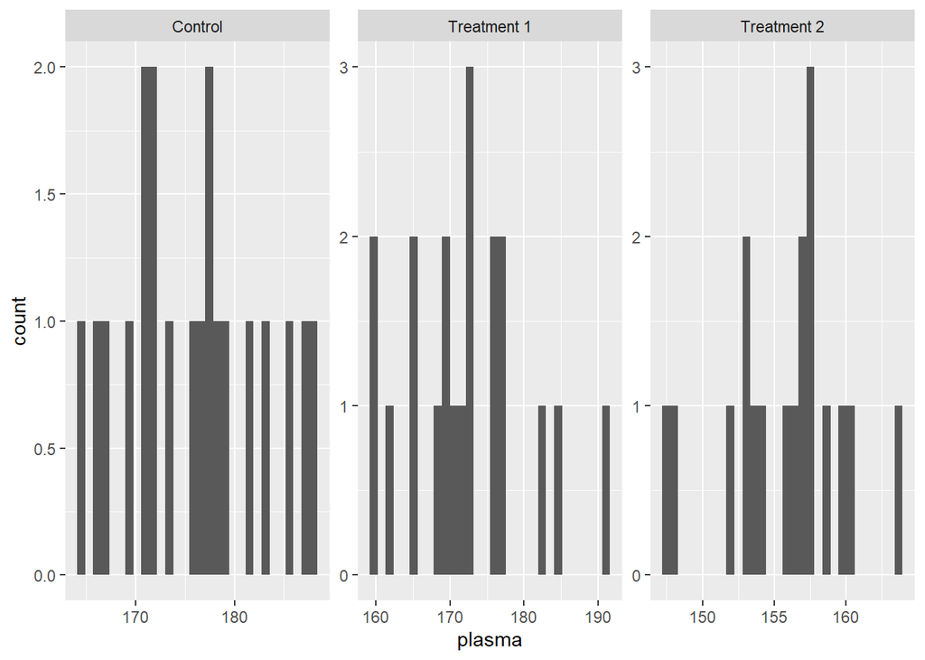

```r
ggplot(plasma_long,aes(plasma))+
  geom_histogram()+
  facet_wrap(~ group,scales = "free")
```

Compare the different groups, one to one!

### use the wide format

We can use t.test(x,y) with x and y the two column we want to compare.

```r
t.test(plasma[,"Treatment 1"],plasma[,"Control"])
```

```
##
##  Welch Two Sample t-test
##
## data:  plasma[, "Treatment 1"] and plasma[, "Control"]
## t = -1.632, df = 37.199, p-value = 0.1111
## alternative hypothesis: true difference in means is not equal to 0
## 95 percent confidence interval:
##  -8.7073822  0.9373822
## sample estimates:
## mean of x mean of y
##   171.985   175.870
```

Here it says: the difference of means between the treatment 1 and control:

```r
mean(plasma$`Treatment 1`) - mean(plasma$Control)
```

```
## [1] -3.885
```

is the estimation of a difference laying between -8.7 and 0.9 (the confidence interval). We thus don’t really know is there is a difference or not. P value: The probability that we obtain a difference between treatment 1 and control at least that big if the null hypothesis is true, that is that the two samples treatment 1 and control comes from the same population (i.e. they are not different, we just sampled the same pouplation twice). There is 0.11 probability to obtain at least this result if treatment and control patients come from the same initial population.

```r
t.test(plasma$`Treatment 2`,plasma$Control)
```

```
##
##  Welch Two Sample t-test
##
## data:  plasma$`Treatment 2` and plasma$Control
## t = -11.01, df = 31.337, p-value = 2.67e-12
## alternative hypothesis: true difference in means is not equal to 0
## 95 percent confidence interval:
##  -23.90459 -16.43541
## sample estimates:
## mean of x mean of y
##    155.70    175.87
```

```r
t.test(plasma$`Treatment 2`,plasma$`Treatment 1`)
```

```
##
##  Welch Two Sample t-test
##
## data:  plasma$`Treatment 2` and plasma$`Treatment 1`
## t = -7.958, df = 28.869, p-value = 9.205e-09
## alternative hypothesis: true difference in means is not equal to 0
## 95 percent confidence interval:
##  -20.47111 -12.09889
## sample estimates:
## mean of x mean of y
##   155.700   171.985
```

### use the long format

You can use a formula:

a formula of the form lhs ~ rhs where lhs is a numeric variable giving the data values and rhs either 1 for a one-sample or paired test or a factor with two levels giving the corresponding groups. We have 3 groups! Select only two.

```r
t.test(plasma ~ group,
       data = plasma_long,
       subset = plasma_long$group %in% c("Control","Treatment 2"))
```

```
##
##  Welch Two Sample t-test
##
## data:  plasma by group
## t = 11.01, df = 31.337, p-value = 2.67e-12
## alternative hypothesis: true difference in means between group Control and group Treatment 2 is not equal to 0
## 95 percent confidence interval:
##  16.43541 23.90459
## sample estimates:
##     mean in group Control mean in group Treatment 2
##                    175.87                    155.70
```

Base R style:

```r
plasma_long_sub <- plasma_long[plasma_long$group %in% c("Control","Treatment 2"),]
t.test(plasma ~ group,data = plasma_long_sub)
```

```
##
##  Welch Two Sample t-test
##
## data:  plasma by group
## t = 11.01, df = 31.337, p-value = 2.67e-12
## alternative hypothesis: true difference in means between group Control and group Treatment 2 is not equal to 0
## 95 percent confidence interval:
##  16.43541 23.90459
## sample estimates:
##     mean in group Control mean in group Treatment 2
##                    175.87                    155.70
```

# Bisphenol data

Here the result of a trial on the effect of bisphenol on cancer. There are 3 groups

- control group: no bisphenol exposition
- Moderate exposition to bisphenol
- High exposition to bisphenol

We want to compare the number of cancer between groups. What is the proper test ???

## aggregated results

```r
df_bisphenol
```

| group | Cancer | NoCancer |
| --- | --- | --- |
| Control | 1 | 29 |
| Moderate exposition | 2 | 28 |
| High exposition | 10 | 20 |

The two columns give you the number of cancer developed in each group (each group is 30 patients)

**Question**: is the proportion of cancer different in each group ?

`chisq.test` takes a contigency matrix!

I can just write the matrix:

```r
matrix(c(1,29,10,20),ncol = 2)
```

```
##      [,1] [,2]
## [1,]    1   10
## [2,]   29   20
```

```r
chisq.test(matrix(c(1,29,10,20),ncol = 2))
```

```
##
##  Pearson's Chi-squared test with Yates' continuity correction
##
## data:  matrix(c(1, 29, 10, 20), ncol = 2)
## X-squared = 7.1243, df = 1, p-value = 0.007605
```

Or I can select the data, base R like

```r
cont_matrix <- as.matrix(df_bisphenol[c(1,3),c(2,3)])
```

Now the test

```r
chisq.test(cont_matrix)
```

```
##
##  Pearson's Chi-squared test with Yates' continuity correction
##
## data:  cont_matrix
## X-squared = 7.1243, df = 1, p-value = 0.007605
```

## detailed result

The results could be long data, with one line for each patient:

```r
Bisphenol_long
```

| group | had_cancer | ID |
| --- | --- | --- |
| Control | 0 | 1 |
| Control | 0 | 2 |
| Control | 0 | 3 |
| Control | 0 | 4 |
| Control | 0 | 5 |
| Control | 0 | 6 |
| Control | 0 | 7 |
| Control | 0 | 8 |
| Control | 0 | 9 |
| Control | 0 | 10 |

[output cut: 80 more lines]

If we make a table, we find back the agregated results from before

```r
table(Bisphenol_long$group,Bisphenol_long$had_cancer)
```

```
##
##                  0  1
##   Control       29  1
##   High_expo     20 10
##   Moderate_expo 28  2
```

The `chisq.test` function can take two variables, one for the group, one for cancer yes no.

```r
chisq.test(Bisphenol_long$had_cancer[Bisphenol_long$group %in% c("Control","High_expo")],
           Bisphenol_long$group[Bisphenol_long$group %in% c("Control","High_expo")])
```

```
##
##  Pearson's Chi-squared test with Yates' continuity correction
##
## data:  Bisphenol_long$had_cancer[Bisphenol_long$group %in% c("Control",
##     "High_expo")] and Bisphenol_long$group[Bisphenol_long$group %in% c("Control", "High_expo")]
## X-squared = 7.1243, df = 1, p-value = 0.007605
```

# help

- lost ? try https://rfortherestofus.com/courses/getting-started/
- read https://r4ds.had.co.nz/, especially
  - https://r4ds.had.co.nz/exploratory-data-analysis.html
  - https://r4ds.had.co.nz/workflow-basics.html